# Data Science Capstone: Quantifying Yelp User Reviews with Sentiment Analysis

Dax Gerts  
22 November 2015

### Natural Language Processing & Predictive Task

One of the most rapidly developing subsets of interest in data science is Natural Language Processing and its various uses. In the case of the Yelp Reviews Dataset, these tools are highly useful in attempting to salvage analytic data from the mass of collected text reviews. While there are a variety of goals and approaches that could be taken in analyzing this data, for the purposes of this report, the point of interest was narrowed to a single predictive goal, described as follows:

**Prediction Task: Can the numeric component of user reviews (stars given) by predicted from the contents of the text provided? Or by evaluating the text in conjunction with other values?**

### Methodology

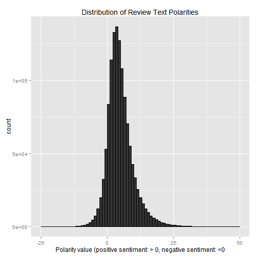

### Results

Training Set Results:

```
      Accuracy          Kappa  AccuracyLower  AccuracyUpper   AccuracyNull
  5.210000e-01   2.828332e-01   4.895145e-01   5.523616e-01   3.640000e-01
AccuracyPValue  McnemarPValue
  3.632701e-24            NaN
```

Test Set Results

```
      Accuracy          Kappa  AccuracyLower  AccuracyUpper   AccuracyNull
    0.30524357     0.06757159     0.30363267     0.30685807     0.36929944
AccuracyPValue  McnemarPValue
    1.00000000     0.00000000
```

### Conclusion & Discussion

This report is truly only an initial analysis of how Natural Language Processing techniques might be applied to various types of user data. As with any type of predictive task, there is never truly a “correct answer” only “better” answers. In this case, I do not believe the model that was created to have significant predictive value on its own, however, I believe that it serves an adequate representation of the fact that analysis of text data can be useful in making up for inadequacies in overly sparse numerical data.